# 處理 LiDAR 資料轉成表面數值地形圖

林政道

October 29, 2014

## 將 LiDAR 資料轉成 STM 網格 (1)

### 概念及做法

LiDAR 掃出來的資料是「點」資料，若要靠這些反射回來的點座標推得一個區域內的數值地形圖(Digital Terrain Map; DTM，雖然 LiDAR 掃出來的應該是「表面」Surface Terrain Model，若要取得真正的數值地形圖則必須要再做轉換)，直覺上最快的作法就是將每個相同座標的點找最小值。假設我們透過 LiDAR 掃描取得的 xyz 座標為(單位為公尺)：

| id | x | y | z |
| --- | --- | --- | --- |
| 1 | -0.1061 | -0.1624 | 1178.482 |
| 2 | -0.1061 | -0.1623 | 1178.475 |
| 3 | -0.1060 | -0.1623 | 1178.474 |
| 4 | -0.1060 | -0.1624 | 1178.481 |
| 5 | -0.1060 | -0.1623 | 1178.473 |
| 6 | -0.1059 | -0.1623 | 1178.472 |

示意圖如下，假設解析度是 1 cm，LiDAR 掃完某區域後，得到七個點，這些點分別投影在平面後，屬於三個網格，接下來只要找每個網格單位內，LiDAR 掃到的點之最低 z 值，就是表面的高度了。將這些 z 值和網格座標彙整，利用 GIS 即可轉換成 raster 格式的 STM。

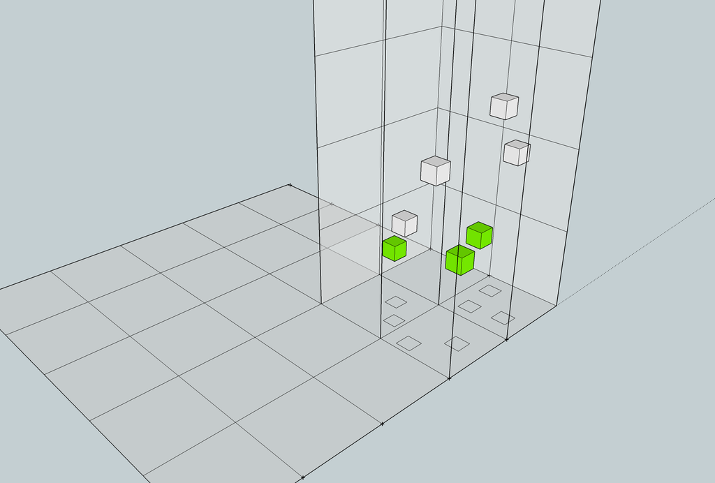

在我們上面的範例資料中，若用 0.1cm 解析度的網格計算，則可得下列表：

| id | x | y | z |
| --- | --- | --- | --- |
| 1 | -0.106 | -0.162 | 1178.482 |
| 2 | -0.106 | -0.162 | 1178.475 |
| 3 | -0.106 | -0.162 | 1178.474 |
| 4 | -0.106 | -0.162 | 1178.481 |
| 5 | -0.106 | -0.162 | 1178.473 |
| 6 | -0.105 | -0.162 | 1178.472 |

計算相同網格座標內的最小值，則會得到：

| id | x | y | z |
| --- | --- | --- | --- |
| 5 | -0.106 | -0.162 | 1178.473 |
| 6 | -0.105 | -0.162 | 1178.472 |

### R 實作

0. 安裝套件

必須安裝的套件(package): raster 選擇性安裝的套件：rhdfs

1. 先將資料匯入，可以使用 `read.csv()`。因為載入資料數量很大，下面例子採用 [RHadoop](https://github.com/RevolutionAnalytics/RHadoop/wiki) 為例，你可以依照需求修改：

```
Sys.setenv(HADOOP_CMD="/usr/local/bin/hadoop")

library(rhdfs)
library(rmr2)
hdfs.init();

# import data into hdfs via hdfs.file()
HDFS_r = hdfs.file("ST000.xyz", "r",buffersize = 104857600)
HDFS_f = hdfs.read(HDFS_F)
data = read.csv(textConnection(rawToChar(HDFS_f)), sep=" ", header=F)
```

如果你不知道什麼是 Hadoop ，請跳過，可直接使用 `read.csv()` 來匯入資料

```r
data = read.csv('~/Documents/Dropbox/projects/LiDAR/lidar_process/sample_data.xyz',
                header=F, sep=" ")
# use head to view top six rows
head(data)
```

```
##        V1      V2   V3   V4
## 1 -0.1061 -0.1624 1178 1366
## 2 -0.1061 -0.1623 1178 1372
## 3 -0.1060 -0.1623 1178 1372
## 4 -0.1060 -0.1624 1178 1381
## 5 -0.1060 -0.1623 1178 1370
## 6 -0.1059 -0.1623 1178 1379
```

上面的資料中，`V1` 至 `V4` 欄位分別代表相對座標 `(x, y, z)` (相對於 LiDAR 儀器擺放的中心)，以及反射強度值。

2. 將 `(x, y)` 座標取出，用無條件捨去法處理

接下來將 dataset 中的 x, y 座標取出來，並假設解析度為 10 cm。因為原始資料單位是公尺，為了方便計算，將其換算為公分後，再無條件捨去，在這個步驟中，我們會使用到 `trunc` 這個函式：

```r
trunc_xy = trunc(data[,1:2]*100/10)*10
head(trunc_xy)
```

```
##    V1  V2
## 1 -10 -10
## 2 -10 -10
## 3 -10 -10
## 4 -10 -10
## 5 -10 -10
## 6 -10 -10
```

```r
trunc_xyz = cbind(trunc_xy, data[,3])

# 為了讓 dataframe 美觀且容易閱讀，我們加上欄位名稱
colnames(trunc_xyz) = c("x", "y", "z")
head(trunc_xyz)
```

```
##     x   y    z
## 1 -10 -10 1178
## 2 -10 -10 1178
## 3 -10 -10 1178
## 4 -10 -10 1178
## 5 -10 -10 1178
## 6 -10 -10 1178
```

3. 使用 `aggregate` 求出相同網格(xy 座標)中的最小值

這個步驟主要是把 `(x, y)` 合併當成一個群組，相當於 group by 的概念，在一個 group 中求出 z 的最小值。

```r
# aggregate(target, by=_grouping_elements, FUN=_function)
aggr_xyz = stats::aggregate(trunc_xyz["z"], by=trunc_xyz[c("x", "y")], FUN=min)
aggr_xyz
```

```
##      x   y    z
## 1  -20 -30 1180
## 2  -10 -30 1179
## 3    0 -30 1180
## 4  -20 -20 1177
## 5  -10 -20 1177
## 6    0 -20 1179
## 7  -30 -10 1179
## 8  -20 -10 1179
## 9  -10 -10 1177
## 10   0 -10 1177
## 11 -20   0 1180
## 12 -10   0 1179
## 13   0   0 1177
```

所以上面的 dataframe 就是我們所要求的 10cm 解析度的網格 xyz 座標值。

4. 寫成函式

整理一下上述步驟，將處理的程序寫成函式，方便後續的處理：

輸入之變數： 資料集(dataframe)、網格解析度(res) 使用的功能函式：`stats::aggregate()`, `base::trunc()`

```r
proc_stm = function(dataframe,res) {
  r_cm = 100
  trunc_xyz = cbind(trunc(dataframe[,1:2]*r_cm/res)*res, dataframe[,3])
  colnames(trunc_xyz) = c("x", "y", "z")
  output = aggregate(trunc_xyz["z"], by=trunc_xyz[c("x","y")], FUN=min)
  return(output)
}
```

處理 STM:

```r
output.xyz = proc_stm(data, 10)
output.xyz
```

```
##      x   y    z
## 1  -20 -30 1180
## 2  -10 -30 1179
## 3    0 -30 1180
## 4  -20 -20 1177
## 5  -10 -20 1177
## 6    0 -20 1179
## 7  -30 -10 1179
## 8  -20 -10 1179
## 9  -10 -10 1177
## 10   0 -10 1177
## 11 -20   0 1180
## 12 -10   0 1179
## 13   0   0 1177
```

5. 將 xyz 座標轉換成 raster 網格

因為 LiDAR 具有距離限制，我們希望以 LiDAR 架設點為原點， 30 公尺的正方形限定範圍：

```r
# limit the target area to 30 by 30 meters
bound=15
output_cm.xyz = output.xyz[(abs(output.xyz[,1]/100) < bound & abs(output.xyz[,2]/100) < bound),]
#換算回公尺
output_m.xyz = cbind(output_cm.xyz[,1:2]/100, output_cm.xyz[,3])
output_m.xyz
```

```
##       x    y output_cm.xyz[, 3]
## 1  -0.2 -0.3               1180
## 2  -0.1 -0.3               1179
## 3   0.0 -0.3               1180
## 4  -0.2 -0.2               1177
## 5  -0.1 -0.2               1177
## 6   0.0 -0.2               1179
## 7  -0.3 -0.1               1179
## 8  -0.2 -0.1               1179
## 9  -0.1 -0.1               1177
## 10  0.0 -0.1               1177
## 11 -0.2  0.0               1180
## 12 -0.1  0.0               1179
## 13  0.0  0.0               1177
```

接下來使用 `rasterFromXYZ()` 將 xyz 座標轉成 raster 格式，並使用 `writeRaster()` 輸出為 GeoTiff raster 格式：

```r
# use raster library to output raster file
library(raster)
rast = rasterFromXYZ(output_m.xyz)
writeRaster(rast, filename = 'output.tif', overwrite=TRUE)
```

[output not shown]

[output not shown]

下圖則是輸出的範例（非本例中之資料輸出）

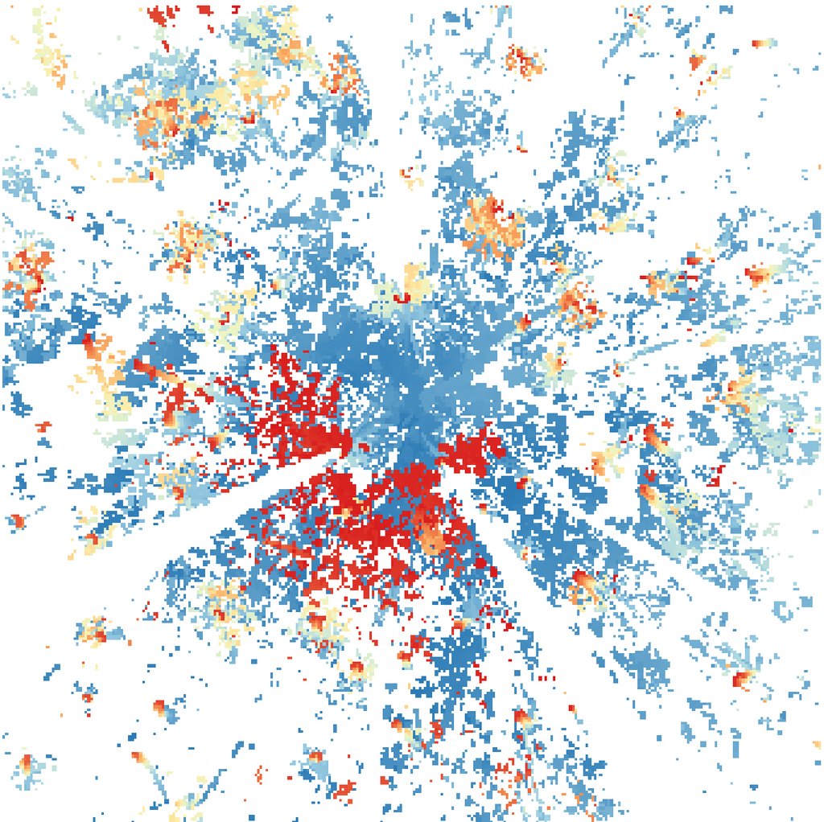